# Worksheet 1 - Scientific Visualisation MVE080/MMG640

## Basics in Python, Jupyter, plotnine and how to visualize amounts

Name: *Houshi He*

This is the first worksheet in the course *Scientific Visualisation*. This Jupyter notebook has three functions:

1. It describes the tasks.
2. It (sometimes) provides coding templates that you can use as a basis for your own code.
3. It is a template also for the report that you upload in Canvas.

The tasks are of various types: some are to read some text and then comment on it (no coding), and some are about creating visualisations using plotnine. Once you have finished all the tasks, export this document as an HTML file and upload it in Canvas. You are encouraged to discuss problems and solutions with your fellow students, but each student must solve all tasks by themselves and hand-in their own report. Notice that Jupyter notebooks use [Markdown](https://docs.github.com/en/github/writing-on-github/getting-started-with-writing-and-formatting-on-github/basic-writing-and-formatting-syntax#links) for writing text cells. Make sure you understand the basics.

Throughout the assignment you shall use a Python workflow. If you are completely new to Python, take a look at this page. Python can do essentially all that MATLAB can, plus more. In this course we shall use Python in different contexts, starting with the [Jupyter Notebook interface](https://jupyter-notebook.readthedocs.io/en/stable/notebook.html).

Matrices and arrays are handled through the NumPy module. [Learn here](https://docs.scipy.org/doc/numpy/user/numpy-for-matlab-users.html) how NumPy is different from MATLAB.

The below loads the packages required for this homework.

```python
import numpy as np
import pandas as pd
from plotnine import *
# Currently in a plotine dependancy they have deprication warning, so
# we mute warnings to have a better experience
import warnings
warnings.filterwarnings("ignore")

# A nice color palette for categorical data
cbPalette = ["#E69F00", "#56B4E9", "#009E73",
             "#F0E442", "#0072B2", "#D55E00",
             "#CC79A7", "#999999"]
```

## Task 1

Read Chapter 1-3 of [Fundamentals of Data Visualizations](https://clauswilke.com/dataviz/), then answer the questions below.

### Question 1.1

Describe the visualisation concept *scales*.

### Answer 1.1

*A scale defines a unique mapping between data and aesthetics, and a scale must be one-to-one, such that for each specific data value there is exactly one aesthetics value and vice versa.*

### Question 1.2

In Figures 2.3 and 2.4, the same data is visualised in two different ways. Discuss the pros and cons of the two approaches. Which one do you prefer and why?

### Answer 1.2

*For Figure 2.3, it's easy to observe the trend as the months change from January to December, and it’s also easier to identify the exact value for any particular month.*

*For Figure 2.4, it uses colors to clearly show the differences in values, making it more intuitive. However, this method doesn't allow us to confirm the exact value for a specific month, as it's difficult to correlate the color with the exact temperature.*

*Personally, I prefer Figure 2.4 because I think it is more beautiful and intuitive. Additionally, Figure 2.4 avoids the issue of line overlap, which may occur in Figure 2.3.*

### Question 1.3

Describe situations when *nonlinear axes* might be useful. When should they not be used?

### Answer 1.3

*When the data range varies significantly, we may use nonlinear axes. For ratio data, we might use a logarithmic scale, and for exponential data, we might use an exponential scale.*

*When the dataset contains negative or zero values, we cannot use a logarithmic scale, as it would be meaningless. When the data changes uniformly, it's better to use linear axes to better express the data's information. If the dataset has extreme values, nonlinear axes may overemphasize these extreme points.*

### Question 1.4

In which situations could a *polar coordinate system* be useful?

### Answer 1.4

*Polar coordinates can be useful for data of a periodic nature, such that data values at one end of the scale can be logically joined to data values at the other end.*

## Task 2 - Tidy data, ggplot and distributions

Several graphics libraries such as ggplot2 and plotnine are at their best when the provided data is tidy. However, data is often not provided in a tidy format, hence being able to transform non-tidy data into tidy data is a crucial skill.

### Question 2.1

In the lecture 1, I provided a small non-tidy dataset (code below).

```python
data1 = pd.DataFrame({"Site" : ["Stockholm", "Gothenburg", "London"],
                      "1999" : [13, 85, 77],
                      "2000" : [21, 31, 15]})
data1
```

|  | Site | 1999 | 2000 |
| --- | --- | --- | --- |
| 0 | Stockholm | 13 | 21 |
| 1 | Gothenburg | 85 | 31 |
| 2 | London | 77 | 15 |

Transform this small dataset into a tidy dataset. Print the table below (as I did above).

*Hint* [melt](https://pandas.pydata.org/docs/reference/api/pandas.melt.html)

```python
data_tran = pd.melt(data1, id_vars='Site', var_name='Year', value_name='Production')
data_tran
```

|  | Site | Year | Production |
| --- | --- | --- | --- |
| 0 | Stockholm | 1999 | 13 |
| 1 | Gothenburg | 1999 | 85 |
| 2 | London | 1999 | 77 |
| 3 | Stockholm | 2000 | 21 |
| 4 | Gothenburg | 2000 | 31 |
| 5 | London | 2000 | 15 |

### Question 2.2

Datasets are often bigger than above. I have made a subset of the weather data used in the lecture non-tidy (available on the webpage).

Transform this dataset into a tidy dataset. Print the table below (as I did above)

```python
# Write your answer here
from pandas.api.types import CategoricalDtype

data = pd.read_csv("Weather_not_tidy.csv")
tidy_data = pd.melt(data,
                    id_vars=['month', 'day', 'hour_of_day'],
                    value_vars=['Temp2009', 'Temp2010'],
                    var_name='year',
                    value_name='temperature')

tidy_data['year'] = tidy_data['year'].str.replace('Temp', '').astype(int)

month_order = CategoricalDtype(['Jan', 'Feb', 'Mar', 'Apr', 'May', 'Jun',
                                'Jul', 'Aug', 'Sep', 'Oct', 'Nov', 'Dec'], ordered=True)
tidy_data['month'] = tidy_data['month'].astype(month_order)

tidy_data = tidy_data.sort_values(by=['year', 'month', 'day']).reset_index(drop=True)
tidy_data = tidy_data[['year', 'month', 'day', 'hour_of_day', 'temperature']]

tidy_data
```

|  | year | month | day | hour_of_day | temperature |
| --- | --- | --- | --- | --- | --- |
| 0 | 2009 | Jan | 1 | 12 | -0.9 |
| 1 | 2009 | Jan | 2 | 12 | -2.2 |
| 2 | 2009 | Jan | 3 | 12 | 4.2 |
| 3 | 2009 | Jan | 4 | 12 | -4.7 |
| 4 | 2009 | Jan | 5 | 12 | -7.8 |
| ... | ... | ... | ... | ... | ... |
| 725 | 2010 | Dec | 27 | 12 | -6.8 |
| 726 | 2010 | Dec | 28 | 12 | -11.0 |
| 727 | 2010 | Dec | 29 | 12 | -10.6 |
| 728 | 2010 | Dec | 30 | 12 | -3.0 |
| 729 | 2010 | Dec | 31 | 12 | -2.7 |

730 rows × 5 columns

## Distributions

For this part reading Chapter 7 and 9 in [Fundamentals of Data Visualizations](https://clauswilke.com/dataviz/) helps.

## Question 3.1

The benefit with tidy data is that it is easy to work with. For this task, use the tidy weather dataset from above and choose three months and by **a density and histogram plot** visualise the differences in temperature between 2009 and 2010 for the chosen months in a readable manner. Make sure to print the visuals below.

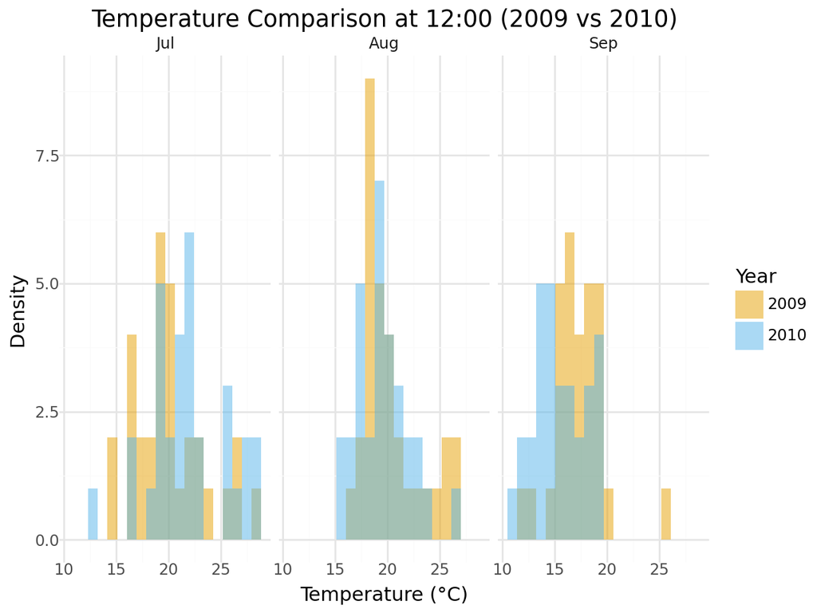

```python
# Filter data for the selected months
selected_months = ['Jul', 'Aug', 'Sep']
filtered_data = tidy_data[tidy_data['month'].isin(selected_months)]

# Create histogram plots
histogram_plot = (
    ggplot(filtered_data, aes(x='temperature', fill='factor(year)'))
    + geom_histogram(aes(y='..count..'), bins=20, position='identity', alpha=0.5)
    + facet_wrap('~month', nrow=1)
    + scale_fill_manual(values=cbPalette[:2], labels=['2009', '2010'])
    + labs(title='Temperature Comparison at 12:00 (2009 vs 2010)',
           x='Temperature (°C)', y='Density', fill='Year')
    + theme_minimal()
)

histogram_plot
```

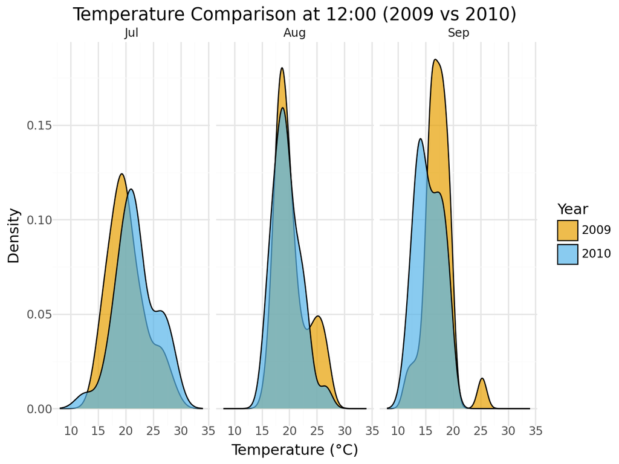

```python
# Insert code here for density plot
# Create density plots
density_plot = (
    ggplot(filtered_data, aes(x='temperature', fill='factor(year)'))
    + geom_density(alpha=0.7)
    + facet_wrap('~month', nrow=1)
    + scale_fill_manual(values=cbPalette[:2], labels=['2009', '2010'])
    + labs(title='Temperature Comparison at 12:00 (2009 vs 2010)',
           x='Temperature (°C)', y='Density', fill='Year')
    + xlim(8, 34)  # Set x-axis limits from 8°C to 34°C
    + theme_minimal()
)

density_plot
# Remember to print the visual
```

Provide a brief motivation for which plot (density and histogram) you find most readable.

*I find the density plot more readable because it provides a smooth, continuous view of the temperature distribution. It clearly shows the trends and differences between years and makes comparisons easier.*

### Question 3.2

In Lecture 2, I used boxplots, error-bars, and violin plots to visualise fluctuations in winter temperature in Västerås. Now using the weather data above, plot the temperature per month (like in Fig. 9.8 [here](https://clauswilke.com/dataviz/boxplots-violins.html)) using error bars, boxplots and violin plots with data points. For each month, plot the temperature for 2009 and 2010 next to each other (see example on webpage).

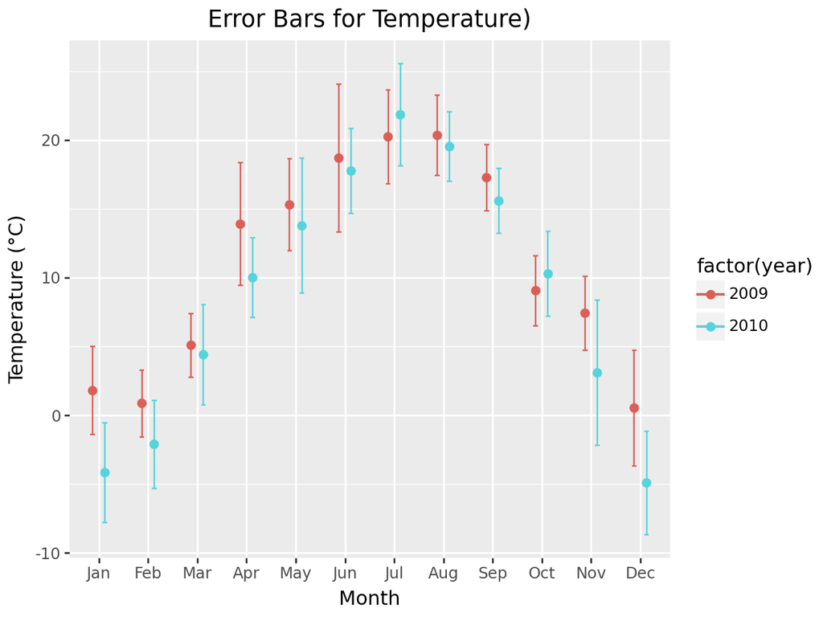

```python
# Insert code here using standard error
# Group data by month and year to calculate mean and standard deviation
mean_temperature = tidy_data.groupby(['month', 'year'])['temperature'].mean().reset_index()
std_temperature = tidy_data.groupby(['month', 'year'])['temperature'].std().reset_index()

# Merge the dataframes to get both mean and standard deviation
temperature_error_data = pd.merge(mean_temperature, std_temperature, on=['month', 'year'], suffixes=('_mean', '_std'))

# Create the plot with error bars
error_bar_plot = (
    ggplot(temperature_error_data, aes(x='month', y='temperature_mean', fill='factor(year)', color='factor(year)'))
    + geom_errorbar(
        aes(ymin='temperature_mean - temperature_std', ymax='temperature_mean + temperature_std'),
        width=0.2,
        position=position_dodge(0.5)  # Dodge for separation between years
    )
    + geom_point(size=2, position=position_dodge(0.5))  # Add points with dodge to align
    + labs(
        title='Error Bars for Temperature)',
        x='Month',
        y='Temperature (°C)'
    )
)

error_bar_plot
# Remember to print the visual
```

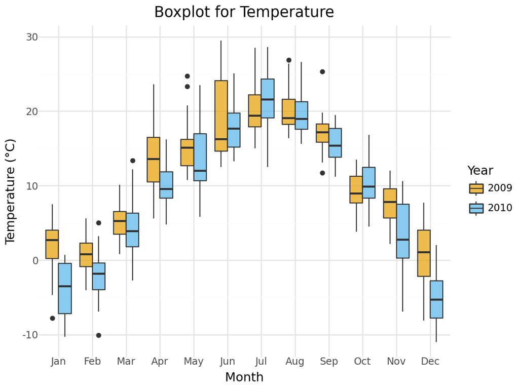

```python
# Insert code here using boxplots
boxplot_plot = (
    ggplot(tidy_data, aes(x='month', y='temperature', fill='factor(year)'))
    + geom_boxplot(position='dodge', alpha=0.7)
    + scale_fill_manual(values=cbPalette[:2], labels=['2009', '2010'])
    + labs(title='Boxplot for Temperature',
           x='Month', y='Temperature (°C)', fill='Year')
    + theme_minimal()
)

boxplot_plot
# Remember to print the visual
```

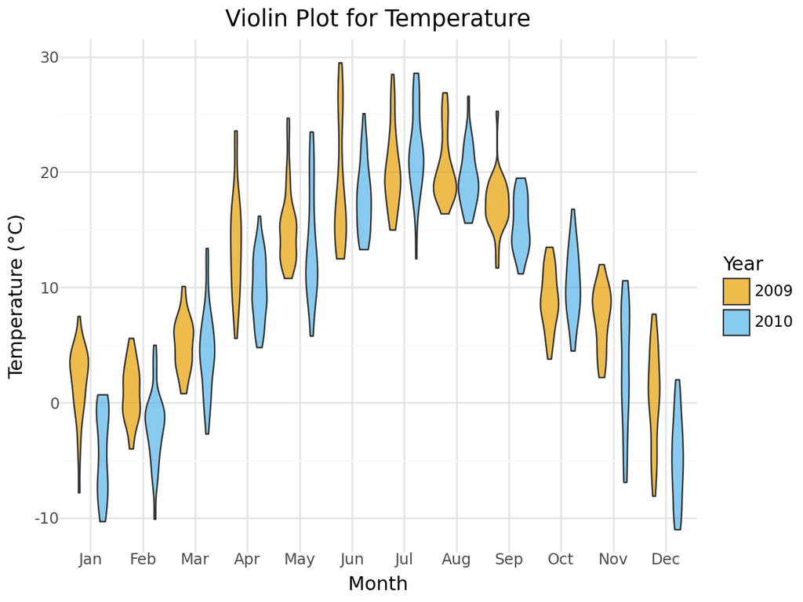

```python
# Insert code here using violin plot with dots
violin_plot = (
    ggplot(tidy_data, aes(x='month', y='temperature', fill='factor(year)'))
    + geom_violin(position='dodge', alpha=0.7)
    + scale_fill_manual(values=cbPalette[:2], labels=['2009', '2010'])
    + labs(title='Violin Plot for Temperature',
           x='Month', y='Temperature (°C)', fill='Year')
    + theme_minimal()
)

violin_plot
# Remember to print the visual
```

Briefly discuss the drawback with each approach (standard errors, boxplots, and violin plots).

**Write answer here**

*Standard errors plot can't show the data distribution, which can be misleading. Boxplots summarize the distribution but don't reveal detailed shapes. Violin plots show density but it could be difficult to interpret with sparse or skewed data.*

One of the drawbacks with a violin plot is that it can be hard to read summary statistics from it. Produce a violin plot visual here, where you have also drawn the median for each violin, as well as the data points.

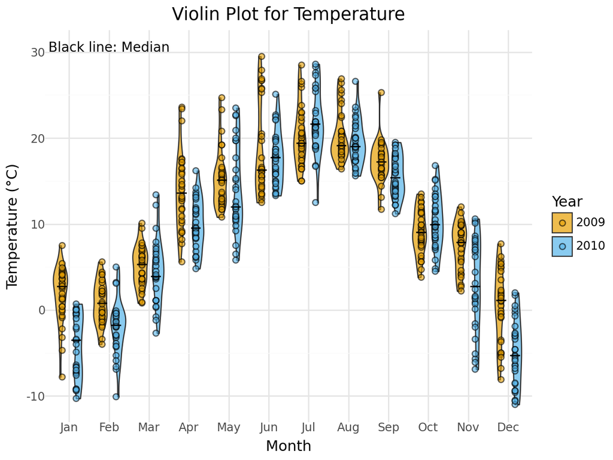

```python
violin_plot = (
    ggplot(tidy_data, aes(x='month', y='temperature', fill='factor(year)'))
    + geom_violin(position='dodge', alpha=0.7)  # Add violin plots
    + scale_fill_manual(values=cbPalette[:2], labels=['2009', '2010'])  # Set colors for the years
    + geom_jitter(size=2, alpha=0.6, position=position_dodge(0.7))  # Add jittered dots for individual data points
    + stat_summary(
        fun_y=np.median,  # Use median for summary statistic
        fun_ymin=np.median,  # ymin is also the median
        fun_ymax=np.median,  # ymax is also the median
        geom='errorbar',  # Use errorbars to indicate the median line
        color='black',  # Color for the median line
        width=0.5,  # Width of the error bar
        position=position_dodge(0.7)  # Dodge to avoid overlap
    )
    + labs(
        title='Violin Plot for Temperature',
        x='Month',
        y='Temperature (°C)',
        fill='Year'
    )
    + theme_minimal()  # Use minimal theme
    + annotate(
        'text', x=2, y=max(tidy_data['temperature']) + 1,
        label='Black line: Median', color='black', size=10, ha='center'
    )  # Add a custom annotation for the median
)

violin_plot
```

Briefly discuss how you could make it easy for the reader to understand that the line the visual represent the median.

**I added an annotation labeling the black line as the median, making it clear and easy for readers to understand its purpose in the visual.**

### Question 3.3

Some people argue that visuals should be as minimal as possible. On the webpage you have a bad example of a minimalist way to plot the min, median, and max temperature of each month in 2009 and 2010 using the dataset in Question 3.2 (where you hopefully have filtered out daily temperatures for 2009 and 2010). By **only** using geom_point recreate the visual (you do not need to recreate the title). **You are not allowed to transform the dataset**.

*Hint - Remember the stat argument in ggplot*

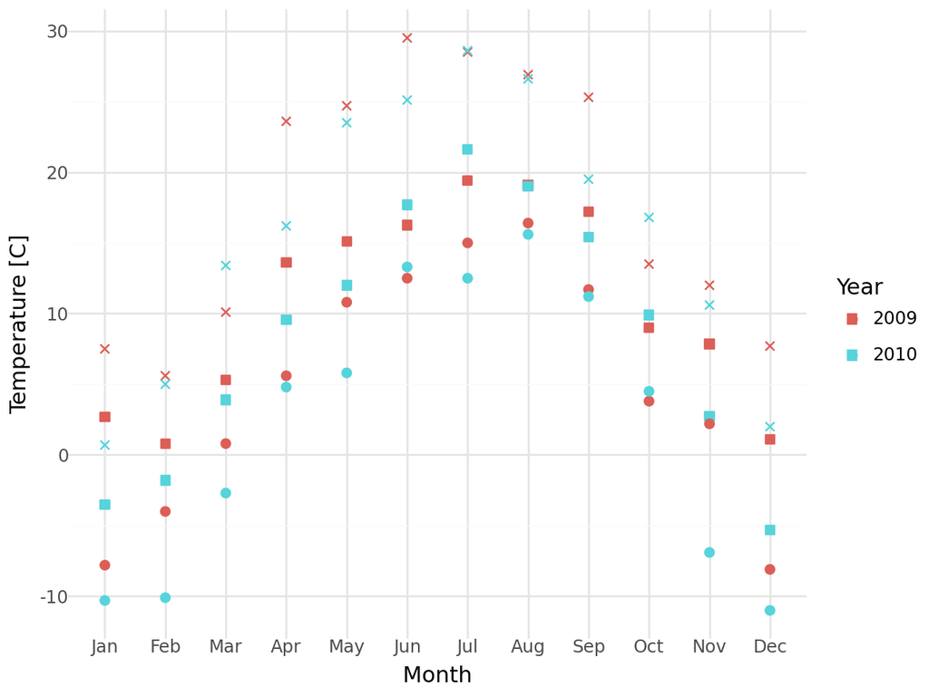

```python
# Insert code here
from plotnine import scale_x_discrete

# Define the order of months
months = ['Jan', 'Feb', 'Mar', 'Apr', 'May', 'Jun', 'Jul', 'Aug', 'Sep', 'Oct', 'Nov', 'Dec']

# Create the plot with min, median, and max temperatures
plot = (ggplot(tidy_data, aes(x='month', y='temperature', color='factor(year)'))  # Group by year
        + stat_summary(fun_y=np.median, geom='point', size=2, shape='s')  # Median points
        + stat_summary(fun_y=np.min, geom='point', size=2, shape='o')  # Min points
        + stat_summary(fun_y=np.max, geom='point', size=2, shape='x')  # Max points
        + scale_x_discrete(limits=months)  # Set the month order
        + labs(x='Month', y='Temperature [C]', color='Year')  # Labels for axes
        + theme_minimal()  # Minimal theme
)

# Display the plot
plot

# Remember to print the visual
```

### Question 3.4

Using the full weather dataset on the webpage create two plots of your on choice. For example, you can compare winter temperatures across years, differences in night and day temperatures etc. For each visual provide a brief motivation on why your choice of visual (e.g violin or boxplot) is a good choice.

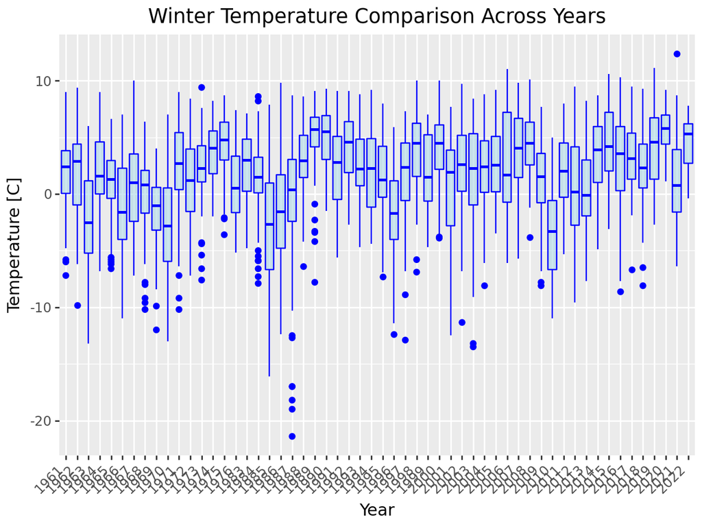

```python
# Load the data
data = pd.read_csv("Weather_tidy_full.csv")

# Filter data for winter months (Dec, Jan, Feb)
winter_months = ['Dec', 'Jan', 'Feb']
winter_data = data[data['month'].isin(winter_months)]

# Filter for 12:00 (noon) temperatures
winter_data_noon = winter_data[winter_data['hour_of_day'] == 12]

# Create a boxplot comparing winter temperatures across years (assuming 'year' is the correct column name)
plot_winter_comparison = (
    ggplot(winter_data_noon, aes(x='factor(year)', y='Temperature'))
    + geom_boxplot(fill='lightblue', color='blue', alpha=0.6)
    + labs(x='Year', y='Temperature [C]', title='Winter Temperature Comparison Across Years')
    + theme(axis_text_x=element_text(angle=45, hjust=1))
)

# Display the plot
plot_winter_comparison
```

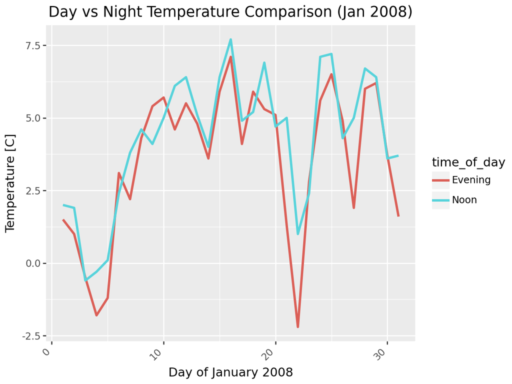

```python
# Load the dataset
data = pd.read_csv('Weather_tidy_full.csv')

# Filter data for 2008 January
data_2008_jan = data[(data['year'] == 2008) & (data['month'] == 'Jan')]

# Select only the noon (12:00) and evening (18:00) temperature data
day_data = data_2008_jan[data_2008_jan['hour_of_day'] == 12]
night_data = data_2008_jan[data_2008_jan['hour_of_day'] == 18]

# Create a new DataFrame with the time of day and corresponding temperatures
day_night_data = pd.concat([day_data[['day', 'Temperature']].assign(time_of_day='Noon'),
                            night_data[['day', 'Temperature']].assign(time_of_day='Evening')])

# Create the line plot comparing daytime and nighttime temperatures for January 2008
plot_day_night_comparison = (
    ggplot(day_night_data, aes(x='day', y='Temperature', color='time_of_day'))
    + geom_line(size=1.2)
    + labs(x='Day of January 2008', y='Temperature [C]', title='Day vs Night Temperature Comparison (Jan 2008)')
    + theme(axis_text_x=element_text(angle=45, hjust=1))  # Rotate x-axis labels for better visibility
)

# Display the plot
plot_day_night_comparison
```

*Brief motivation*

*A line plot is used to compare daytime and nighttime temperatures, clearly showing the daily temperature fluctuations and the difference between day and night in January 2008.*

## Amounts

For this part reading Chapter 6 in [Fundamentals of Data Visualizations](https://clauswilke.com/dataviz/) can help.

### Question 4.1

Barplots are the workhorse for plotting amounts. Create a dataframe with the values from Tab. 6.1 in the [course book](https://clauswilke.com/dataviz/visualizing-amounts.html), and recreate Fig. 6.1 and Fig. 6.3 in the course book.

```
   Rank                           Title     gross
0     1        Star Wars: The Last Jedi  71565498
1     2  Jumanji: Welcome to the Jungle  36169328
2     3                 Pitch Perfect 3  19928525
3     4            The Greatest Showman   8805843
4     5                       Ferdinand   7316746
```

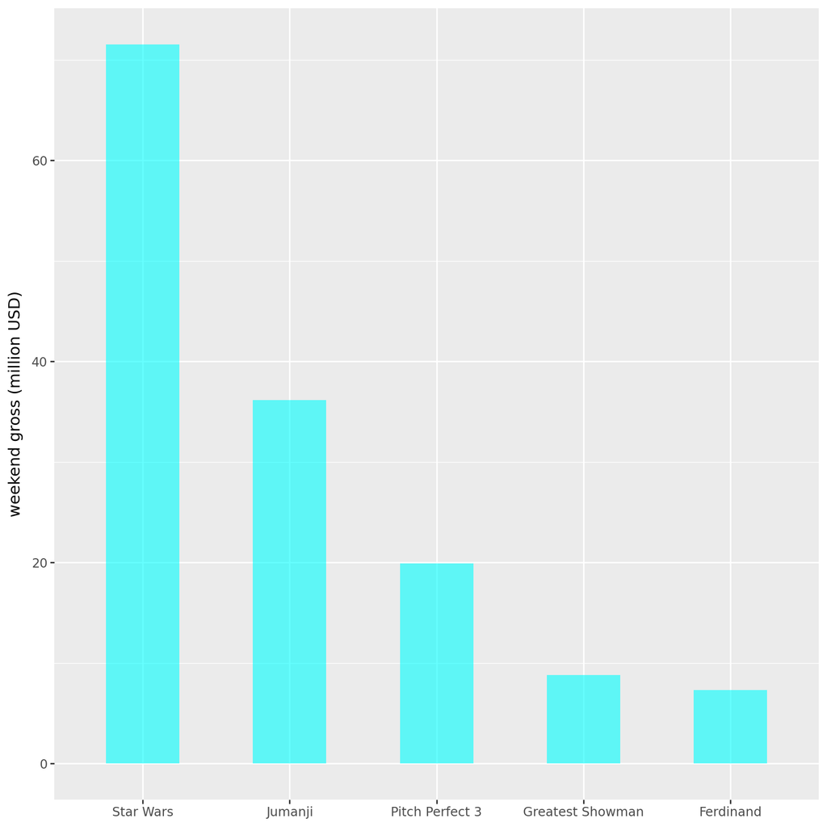

```python
# Insert code here for Fig. 6.1
data = pd.DataFrame({'Rank':[1,2,3,4,5],
                     'Title':['Star Wars: The Last Jedi','Jumanji: Welcome to the Jungle', 'Pitch Perfect 3', 'The Greatest Showman', 'Ferdinand'],
                     'gross': [71565498, 36169328, 19928525, 8805843, 7316746]})
data = data.sort_values(by=['gross'], ascending=False)
print(data.head())


plot = (ggplot(data, aes('Title', 'np.divide(gross,1000000)'))
        + geom_bar(position='dodge', stat='identity', fill='cyan', alpha=0.6, width=0.5)
        + scale_x_discrete(limits=data['Title'], labels=['Star Wars', 'Jumanji', 'Pitch Perfect 3', 'Greatest Showman', 'Ferdinand'])
        + ylab('weekend gross (million USD)')
        + xlab('')
        + theme(figure_size=(8,8)))

plot
# Remember to print the visual
```

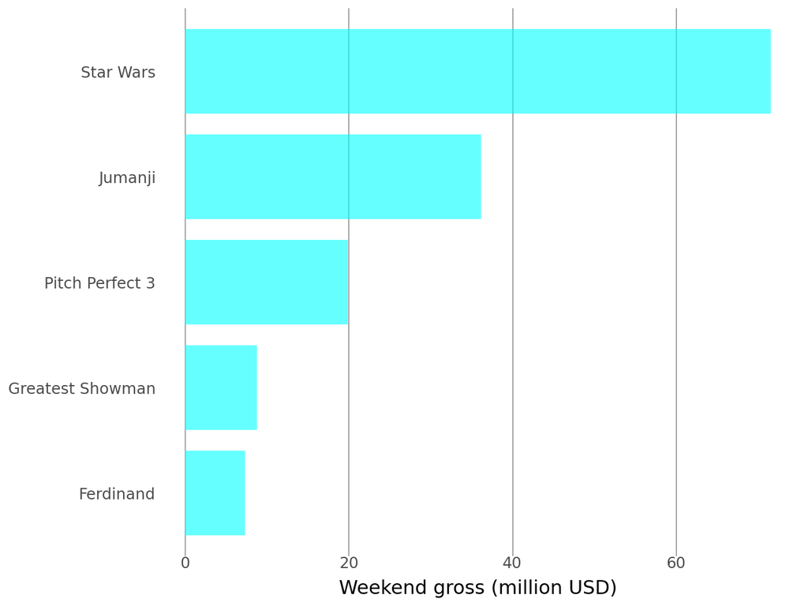

```python
# Insert code here for Fig. 6.2
# Sort the data by 'gross' in ascending order
data = data.sort_values(by=['gross'])

# Define and reverse the titles for the x-axis labels
titles = ['Star Wars', 'Jumanji', 'Pitch Perfect 3', 'Greatest Showman', 'Ferdinand']
titles.reverse()

# Create the bar plot
plot = (
    ggplot(data, aes(x='Title', y='gross / 1000000'))  # Plot gross in millions
    + geom_bar(position='dodge', stat='identity', fill='cyan', alpha=0.6, width=0.8)  # Bars with custom width and transparency
    + scale_x_discrete(limits=data['Title'], labels=titles)  # Ensure correct order and labels for titles
    + scale_y_continuous(breaks=[0, 20, 40, 60])  # Show only 0, 20, 40, 60 on y-axis
    + ylab('Weekend gross (million USD)')  # Add y-axis label
    + xlab('')  # Remove x-axis label
    + coord_flip()  # Flip the coordinates for horizontal bars
    + theme_minimal()  # Use a minimal theme
    + theme(
        panel_grid_major_y=element_blank(),  # Remove horizontal grid lines
        panel_grid_minor_y=element_blank(),  # Remove minor grid lines
        panel_grid_minor_x=element_blank(),  # Remove all minor x grid lines
        panel_grid_major_x=element_line(color="gray", size=0.5),  # Show only major x grid lines (0, 20, 40, 60)
        axis_line=element_blank()  # Remove all axis lines
    )
)

plot


# Remember to print the visual
```

### Question 4.2

Often we want to highlight a specific column in a barplot. Using the same layout as in the most recent plot highlight the column of Jumanji in orange, and keep the remaining columns grey.

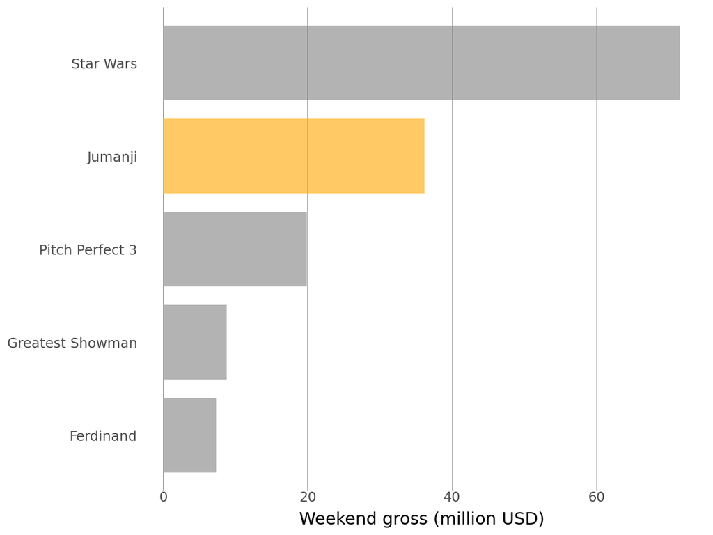

```python
# Insert code here
# Sort the data by 'gross' in ascending order
data = data.sort_values(by=['gross'])

# Define and reverse the titles for the x-axis labels
titles = ['Star Wars', 'Jumanji', 'Pitch Perfect 3', 'Greatest Showman', 'Ferdinand']
titles.reverse()

# Create a new column for fill color
data['fill_color'] = ['orange' if title == 'Jumanji: Welcome to the Jungle' else 'grey' for title in data['Title']]

# Create the bar plot
plot = (
    ggplot(data, aes(x='Title', y='gross / 1000000', fill='fill_color'))  # Map fill color based on the condition
    + geom_bar(position='dodge', stat='identity', alpha=0.6, width=0.8)  # Bars with custom width and transparency
    + scale_fill_identity()  # Use the exact fill colors defined in the data
    + scale_x_discrete(limits=data['Title'], labels=titles)  # Ensure correct order and labels for titles
    + scale_y_continuous(breaks=[0, 20, 40, 60])  # Show only 0, 20, 40, 60 on y-axis
    + ylab('Weekend gross (million USD)')  # Add y-axis label
    + xlab('')  # Remove x-axis label
    + coord_flip()  # Flip the coordinates for horizontal bars
    + theme_minimal()  # Use a minimal theme
    + theme(
        panel_grid_major_y=element_blank(),  # Remove horizontal grid lines
        panel_grid_minor_y=element_blank(),  # Remove minor grid lines
        panel_grid_minor_x=element_blank(),  # Remove all minor x grid lines
        panel_grid_major_x=element_line(color="gray", size=0.5),  # Show only major x grid lines (0, 20, 40, 60)
        axis_line=element_blank()  # Remove all axis lines
    )
    + theme(legend_position='none')
)

plot

# Remember to print the visual
```

Besides using colours to highlight, adding numbers for the highlighted category can also help. For the Jumanji column also add the number that the bar corresponds to.

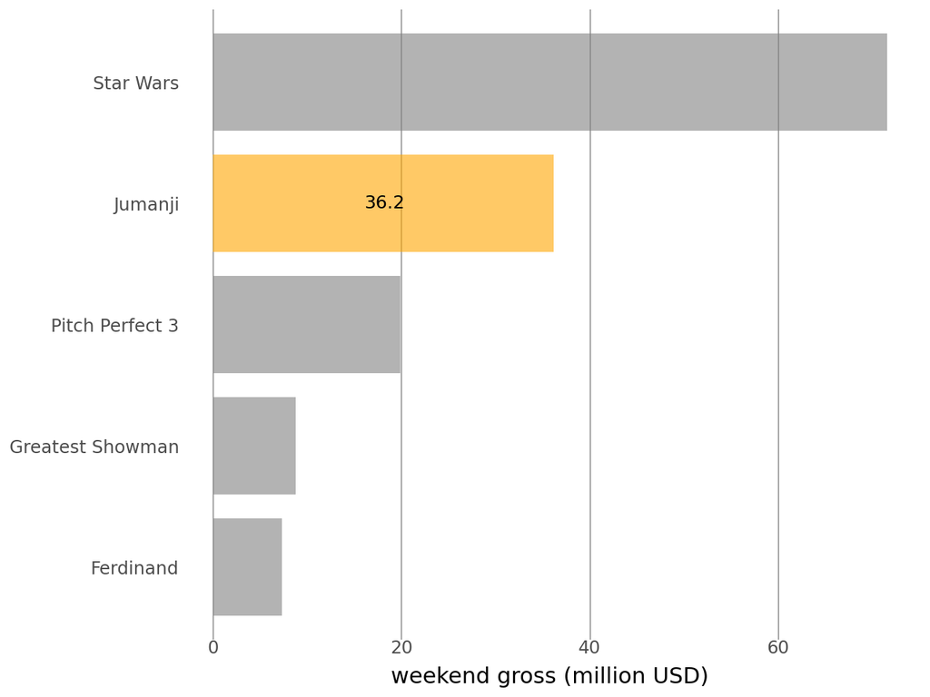

```python
# Add the numeric labels for the highlighted category (Jumanji)
# Sort the data by 'gross' in ascending order
data = data.sort_values(by=['gross'])

# Define and reverse the titles for the x-axis labels
titles = ['Star Wars', 'Jumanji', 'Pitch Perfect 3', 'Greatest Showman', 'Ferdinand']
titles.reverse()

# Create a new column for fill color
data['fill_color'] = ['orange' if title == 'Jumanji: Welcome to the Jungle' else 'grey' for title in data['Title']]

# Create a new column for labels with the rounded 'gross' value
data['label'] = data['gross'] / 1000000  # In million USD

# Create the bar plot
plot = (
    ggplot(data, aes(x='Title', y='gross / 1000000', fill='fill_color'))  # Map fill color based on the condition
    + geom_bar(position='dodge', stat='identity', alpha=0.6, width=0.8)  # Bars with custom width and transparency
    + scale_fill_identity()  # Use the exact fill colors defined in the data
    + scale_x_discrete(limits=data['Title'], labels=titles)  # Ensure correct order and labels for titles
    + scale_y_continuous(breaks=[0, 20, 40, 60])  # Show only 0, 20, 40, 60 on y-axis
    + ylab('weekend gross (million USD)')  # Add y-axis label
    + xlab('')  # Remove x-axis label
    + coord_flip()  # Flip the coordinates for horizontal bars
    + theme_minimal()  # Use a minimal theme
    + theme(
        panel_grid_major_y=element_blank(),  # Remove horizontal grid lines
        panel_grid_minor_y=element_blank(),  # Remove minor grid lines
        panel_grid_minor_x=element_blank(),  # Remove all minor x grid lines
        panel_grid_major_x=element_line(color="gray", size=0.5),  # Show only major x grid lines (0, 20, 40, 60)
        axis_line=element_blank()  # Remove all axis lines
    )
    + theme(legend_position='none')  # Hide the legend
)

# Add the numeric labels for the highlighted category (Jumanji)
plot = plot + geom_text(
    data=data[data['Title'] == 'Jumanji: Welcome to the Jungle'],  # Filter to highlight only Jumanji
    mapping=aes(x='Title', y='gross / 1000000', label=round(data[data['Title'] == 'Jumanji: Welcome to the Jungle']['label'].values[0], 1)),  # Use the value for Jumanji only
    nudge_y=-18,  # Adjust the text position slightly above the bar
    color='black',  # Text color
    size=9  # Text size
)

# Display the plot
plot

# Remember to print the visual
```

### Question 4.3

On the webpage, I have uploaded a dataset on the number of marriages in Stockholm, Gothenburg, Malmo and rest of Sweden for 2020, 2015, 2010 and 2005. Using this dataset, produce i) a visual where it is easy to see which year Stockholm had the second most marriages, and ii) a visual where it is easy to see how many more marriages there was in Stockholm compared to Gothenburg in 2015. **In each visual, I want you to include the number of marriages for each city and year**.

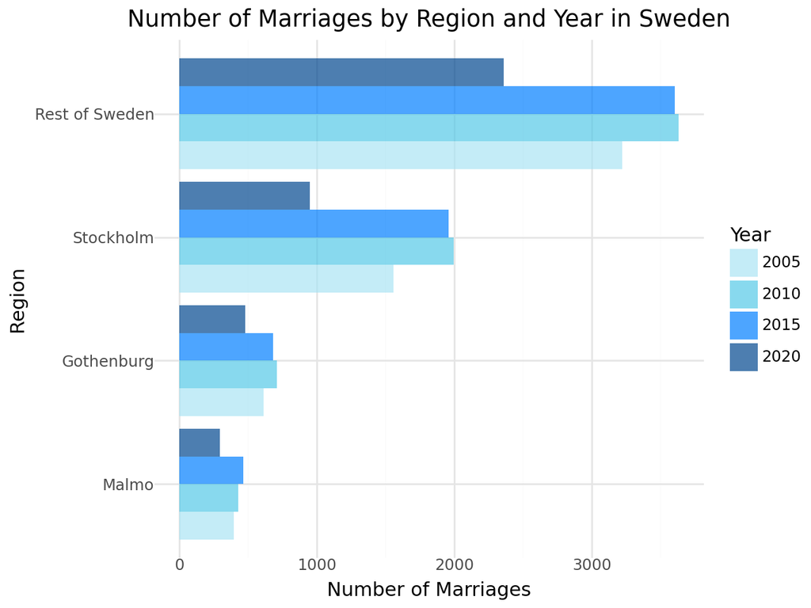

```python
# Insert code here for part i)
# Load the dataset
df = pd.read_csv('Marriage.csv')

# Ensure categorical columns are set correctly
df['region'] = pd.Categorical(df['region'])
df['year'] = pd.Categorical(df['year'])

# Define color palette
color_palette = ['#aae4f3', '#55c8e7', '#007eff', '#00468e']

# Define the order and names for the regions and years
regions_order = ['Rest_of_sweden', 'Stockholm', 'Gothenburg', 'Malmo']
regions_names = ['Rest of Sweden', 'Stockholm', 'Gothenburg', 'Malmo']

# Reverse region order for plot
regions_names.reverse()
regions_order.reverse()

# Set region as a categorical variable with specific order
df['region_cat'] = pd.Categorical(df['region'], categories=regions_order)

# Define the year categories and reverse for plotting
year_categories = [2005, 2010, 2015, 2020]
year_categories.reverse()

# Set year as a categorical variable with specific order
df['year_cat'] = pd.Categorical(df['year'], categories=year_categories)

# Sort values by year to maintain chronological order in the plot
df = df.sort_values('year_cat')

# Create the bar plot with number labels
plot = (
    ggplot(df, aes(x='region_cat', y='number_marriges', fill='year'))  # Mapping the variables to axes and color
    + geom_bar(stat='identity', position='dodge', alpha=0.7)  # Bar chart with dodged bars
    + labs(y='Number of Marriages', x='Region', title='Number of Marriages by Region and Year in Sweden')  # Titles and axis labels
    + scale_fill_manual(values=color_palette, name='Year')  # Manual fill colors for each year
    + scale_x_discrete(limits=regions_order, labels=regions_names)  # Ensure correct region order and labels
    + coord_flip()  # Flip coordinates for horizontal bars
    + theme_minimal()  # Apply minimal theme for clean design
)

# Display the plot
plot
# Remember to print the visual
```

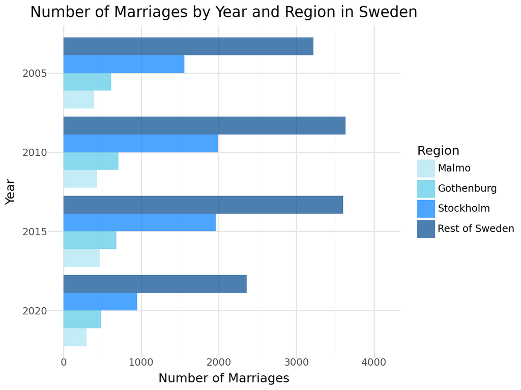

```python
# Insert code here for part ii)
# Create the bar plot with year on the y-axis and region on the x-axis
plot = (
    ggplot(df, aes(x='year_cat', y='number_marriges', fill='region_cat'))  # x: year, y: number of marriages, fill by region
    + geom_bar(stat='identity', position='dodge', alpha=0.7)  # Bar chart with dodged bars for each year, grouped by region
    + labs(x='Year', y='Number of Marriages', title='Number of Marriages by Year and Region in Sweden')  # Titles and axis labels
    + scale_fill_manual(values=color_palette, name='Region', labels=regions_names)  # Manual fill colors for regions
    + scale_x_discrete(limits=year_categories, labels=[str(year) for year in year_categories])  # Set the correct order and labels for years
    + scale_y_continuous(labels=lambda l: [f'{int(x)}' for x in l], limits=(0, df['number_marriges'].max() + 500))  # Display number labels for y-axis
    + coord_flip()  # Flip the coordinates to make the chart horizontal (years on y-axis, regions on x-axis)
    + theme_minimal()  # Apply minimal theme for clean design
)

# Display the plot
plot

# Remember to print the visual
```

### Question 4.4

When plotting the mobile operating system data in the lectures, I used a classical barplot. Another way which makes it easy to track the trend over several years or across companies is a common line-plot. Using the dataset on the webpage recreate the present on the webpage.

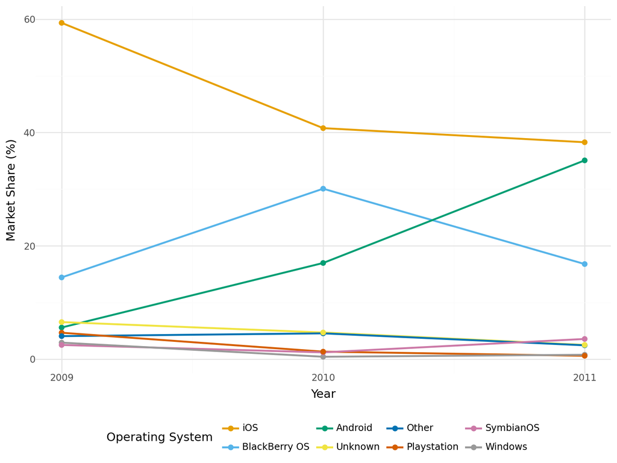

```python
# Insert code here
# Load the mobile OS market share data
os_market_data = pd.read_csv('mobile_os_market_share.csv')

# Filter the data for the years 2009, 2010, and 2011
filtered_os_data = os_market_data.query('Year == 2009 or Year == 2010 or Year == 2011')

# Define the order of operating systems
os_order = ["iOS", "BlackBerry OS", "Android", "Unknown", "Other", "Playstation", "SymbianOS", "Windows"]

# Assign the operating system as a categorical variable to ensure the correct ordering
filtered_os_data = filtered_os_data.assign(OperatingSystem=pd.Categorical(filtered_os_data["OperatingSystem"],
                                                                         categories=os_order))

# Create the plot using ggplot
os_line_plot = (
    ggplot(filtered_os_data, aes(x='Year', y='Share', color='OperatingSystem'))  # Set axes and color by OS
    + geom_line(size=1)  # Add line plot with a line width of 1
    + geom_point(size=2)  # Add points to the plot
    + scale_x_continuous(breaks=[2009, 2010, 2011])  # Specify x-axis ticks for the years
    + scale_color_manual(values=cbPalette)  # Set custom color palette for the operating systems
    + labs(y='Market Share (%)', x='Year')  # Add axis labels
    + theme_minimal()  # Use minimal theme
    + guides(color=guide_legend(title='Operating System', nrow=2))  # Customize legend
    + theme(figure_size=(8, 6), legend_position='bottom')  # Place the legend at the bottom
)

# Display the plot
os_line_plot
# Remember to print the visual
```

By default plotnine places the legend for a visual to the right, or bottom depending on a theme. Do you think having a legend next to the visual is the best solution?

**No, placing the legend next to the visual isn't always ideal, especially with many items. It can crowd the plot. Placing it below may provide more space and improve readability.**

### Question 4.5

In the lecture, I provided data on European nations median lifespan. Now using the full dataset provided on the webpage, select a subset of countries and visualise i) life-expectancy across a timespan of your choice and ii) life expectancy in 2020. Provide a brief motivation for your choice of visual - and why your choice is readable.

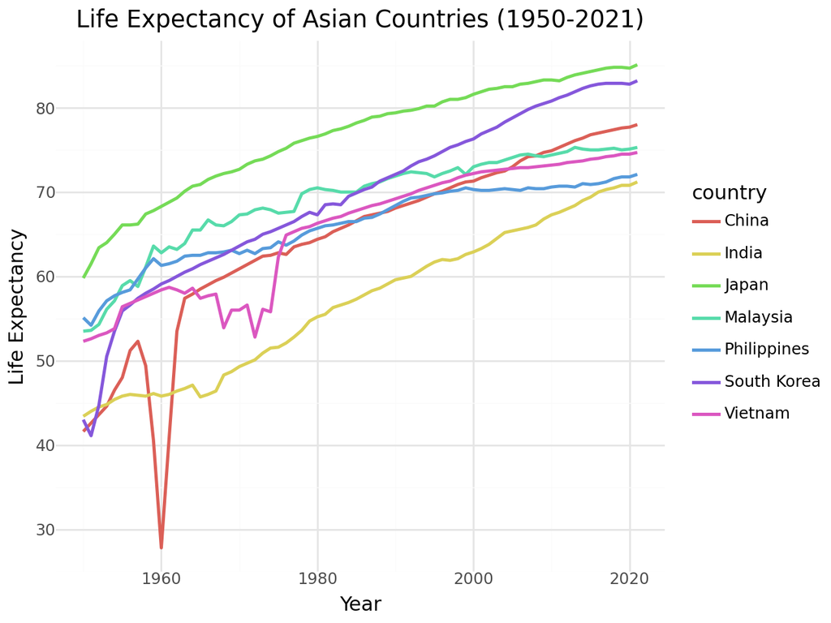

```python
# Insert code here for part1
# Read the CSV file into a DataFrame
data = pd.read_csv('Life_tidy_full.csv')

# Filter data for the countries of interest and years between 1950 and 2021
countries_of_interest = ['South Korea', 'China', 'Japan', 'Vietnam', 'India', 'Philippines', 'Malaysia']
years_of_interest = range(1950, 2022)  # Years from 1950 to 2021

# Filter the DataFrame based on the selected countries and years
filtered_data = data[(data['country'].isin(countries_of_interest)) &
                     (data['Year'].isin(years_of_interest))]

# Display the first few rows of the filtered data to check

# Create a line plot with ggplot
# x-axis: 'Year', y-axis: 'Life_expactancy', color by 'country'
plot = (ggplot(filtered_data)
        + aes(x='Year', y='Life_expactancy', color='country')
        + geom_line(size=1)
        + labs(title='Life Expectancy of Asian Countries (1950-2021)',  # Title of the plot
               x='Year', y='Life Expectancy')  # Labels for the x and y axes
        + theme_minimal())  # Use a minimal theme for the plot

# Display the plot
plot
# Remember to print the visual
```

*Brief motivation*

*I chose a line chart to display the changes in life expectancy for countries in Asia from 1950 to 2021. Line charts are ideal for showcasing trends in time series data, allowing for easy comparison of growth rates and trends across different countries.*

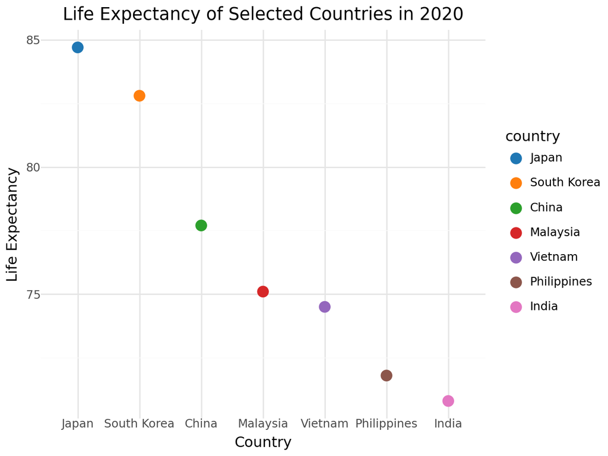

```python
# Insert code here for part2
# Read the CSV file into a DataFrame
data = pd.read_csv('Life_tidy_full.csv')

# Select the countries of interest
countries_of_interest = ['South Korea', 'China', 'Japan', 'Vietnam', 'India', 'Philippines', 'Malaysia']

# Filter the data for the selected countries and the year 2020
filtered_data_2020 = data[(data['country'].isin(countries_of_interest)) & (data['Year'] == 2020)]

# Sort the data by 'Life_expactancy' in descending order
filtered_data_2020 = filtered_data_2020.sort_values(by='Life_expactancy', ascending=False)

# Update the country column to maintain the sorted order in the plot
filtered_data_2020['country'] = pd.Categorical(filtered_data_2020['country'],
                                               categories=filtered_data_2020['country'],
                                               ordered=True)

# Define a color palette to avoid automatic scale issues
color_palette = ['#1f77b4', '#ff7f0e', '#2ca02c', '#d62728', '#9467bd', '#8c564b', '#e377c2']

# Create a scatter plot
plot = (ggplot(filtered_data_2020)
        + aes(x='country', y='Life_expactancy', color='country')  # x-axis: 'country', y-axis: 'Life_expactancy'
        + geom_point(size=4)  # Scatter points size
        + scale_color_manual(values=color_palette)  # Explicitly set color palette
        + labs(title='Life Expectancy of Selected Countries in 2020',  # Title of the plot
               x='Country', y='Life Expectancy')  # Labels for the x and y axes
        + theme_minimal())

# Display the plot
plot
# Remember to print the visual
```

*Brief motivation*

*The scatter plot is chosen to clearly compare life expectancy across countries, highlighting differences in 2020 values with distinct data points for each country.*